# Training a random forest classifier to forecast round winner in CS:GO

## Idea of the analysis

Multiple factors play in to winning a game in sports, be it a traditional football (soccer) or esports. Of course, in soccer a winner is decided by the amount of goals scored but that’s not the entire story of the game. Things happen that allow us to **forecast winner** before the game is even past half time. With talking of football I’m going out of my depth but I’m fairly certain, that the team that manages to have a higher possession of the ball wins more often. This is, as it’s only logical that having a ball generates scoring opportunites which generate goals. The fact that we are confident that on first half other team was obviously better at controlling should forecast that the team is also better at controlling the ball on latter half, and thus more likely to score.

In eSports, such as CS:GO, a round **outcome is dependant of the starting money**, or economy as we call it. The more money you have, more likely you are to win (shortly, money buys things, things help). Granted, this is something that’s easy to see and understand, I was curious of how random the outcome actually is, i.e. how well can a machine **learn to predict the outcome of a round with beforehand known variables.**

## Data

Data is from **CS:GO major tournaments** between 2015 and 2017. The data is originally scarepd from the HLTV.org with https://github.com/ReagentX/HLTV-Scraper (credit to ReagentX). Out of the data I dropped rounds that are considered *pistol rounds*, in layman’s terms it’s a starting round of the half. On those rounds, the starting economy is always equal and winner is thus almost 100% random (50-50 odds). Why almost? In CS:GO contestants aren’t on an even playing field, but the difference of odds to winning a round doesn’t come from economy: it comes from starting side and map. Here’s the data after it has been cleaned up with beforementioned reasoning.

|  | Map | Winner | CTEV | TEV |
| --- | --- | --- | --- | --- |
| 2 | de_dust2 | CT | 20550 | 1900 |
| 3 | de_dust2 | T | 23300 | 23300 |
| 4 | de_dust2 | T | 1200 | 23600 |
| 5 | de_dust2 | T | 6600 | 25450 |
| 6 | de_dust2 | T | 27300 | 20900 |
| 7 | de_dust2 | CT | 1400 | 25950 |
| 8 | de_dust2 | T | 27400 | 23300 |
| 9 | de_dust2 | T | 2500 | 23300 |
| 10 | de_dust2 | CT | 25350 | 23800 |
| 11 | de_dust2 | T | 26850 | 21550 |

[output cut: 11964 more lines]

[figure not shown]

```r
#### Reading and cleaning data
setwd('C:/Users/marku/Downloads')
datasheet <- read.xlsx('majors.xlsx', sheet=2)
datasheet <- datasheet[datasheet$Winner!='SPEC',] #DROP SPEC-WIN ROUNDS
datasheet <- datasheet[datasheet$Type!='Pistol round',] #DROP PISTOL ROUNDS (UNPREDICTABLE/NOISE)
csdata <- datasheet[c('Map', 'Winner', 'Equipement.value.team.1', 'Equipement.value.team.2')]
colnames(csdata)[2] <- 'Winner'; colnames(csdata)[3] <- 'CTEV'; colnames(csdata)[4] <- 'TEV'; #Names
csdata <- csdata[csdata$CTEV!=0,]; csdata <- csdata[csdata$TEV!=0,] #DROP IMPOSSIBLE ROUNDS
csdata$Map <- as.factor(csdata$Map);csdata$Winner <- as.factor(csdata$Winner)
csdata$CTEV <- as.double(csdata$CTEV); csdata$TEV <- as.double(csdata$TEV)
```

*For a non CS:GO player it can be interesting to see clear clusters in the density plot: these are a result of systematic saving*

## Building the classifier

The idea is, that we train a random forest classifier and use the economy (and map, if it matters), to forecast round outcome. So in short I trained classifiers with independant variables such as map, CTEV and TEV. The classifier should be able to have some accuracy in predicting the winner with given variables as can be deducted from the graph above: For example, in a cluster where TEV = ~6,000 and CTEV = ~20,000 CT on average is a clear winner and when economy is vice versa Ts win more.

```r
#### Splitting data to training and testing sets
set.seed(123)
split <- sample.split(csdata$Winner, SplitRatio = 0.8) #80% in training, 20% in testing
training_data <- csdata[split,]
testing_data <- csdata[!split,]

#### Building a classifier
classifier <- randomForest(Winner ~ Map + CTEV + TEV,
                           data = training_data,
                           ntree = 6666)

#### Predicting testing data with classifier trained with training data
testing_predict <- predict(classifier, newdata = testing_data)
testing_confusion <- table(testing_predict, testing_data$Winner)
sum(diag(testing_confusion))/sum(testing_confusion)
```

## Results

[output not shown]

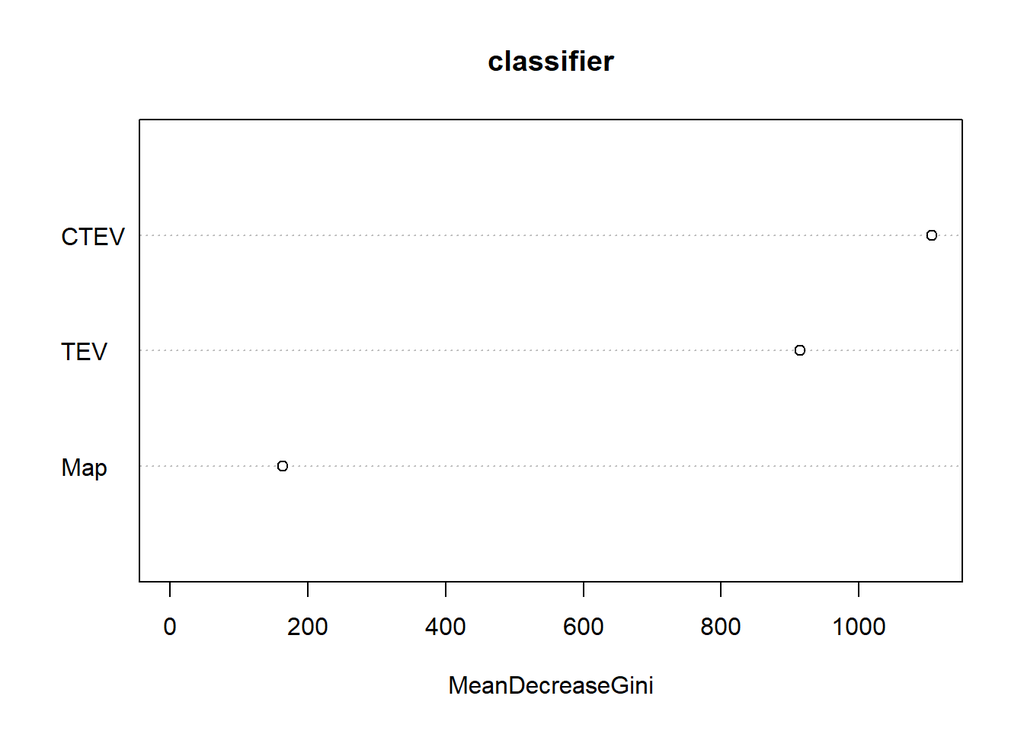